# Homework 1 - Report

Philippossian , Léonard and Pitteloud, David

07 mai, 2019

To obtain the maximum number of points, use whenever possible:

- the pipeline symbol %>%,
- `dplyr` verbs (see below),
- `kable` to print tables,
- `ggplot` to produce the figures.

| verb | description |  |
| --- | --- | --- |
| `select()` | select columns |  |
| `filter()` | filter rows |  |
| `arrange()` | re-order or arrange rows |  |
| `mutate()` | create new columns |  |
| `summarise()` | summarise values |  |
| `group_by()` | group operations |  |

#### Exercise 1: Setup

**1.a** Install the tidyverse and knitr.

```r
#install.packages("tidyverse")
#install.packages("knitr")
```

**1.b** Load the `tidyverse`, `knitr`, and set the precision to 2 digits.

```r
library(tidyverse)
library(knitr)
options(digits=2)
```

#### Exercise 2: Edgar Anderson’s Iris Data

In this exercise, you will analyze a well-known `iris` dataset, which you studied in Machine Learning In Business Analytics course. The dataset contains measurements in centimeters of the variables sepal length and width and petal length and width, respectively for each type of iris, namely, setosa, versicolor, and virginica.

**2.a** Load the dataset `iris` and convert it into `tibble`. How many columns does the dataset have? Name data types of these columns.

```r
data(iris)

tibble.iris <- as_tibble(iris)

#number of columns

kable(ncol(tibble.iris), col.names = "Number of columns in the iris Data set",
      align= 'l')
```

| Number of columns in the iris Data set |
| --- |
| 5 |

```r
#class of columns

column_class<- tibble.iris %>%
    summarise_all(class) %>%
    gather(variable, class)

kable(column_class)
```

| variable | class |
| --- | --- |
| Sepal.Length | numeric |
| Sepal.Width | numeric |
| Petal.Length | numeric |
| Petal.Width | numeric |
| Species | factor |

**2.b** Print out only species and its length of a sepal in ascending order. Print out same columns in using descending order of sepal length.

```r
S_L_Ascending <- tibble.iris %>%
  arrange(Sepal.Length) %>%
  select(Sepal.Length, Species)

kable(head(S_L_Ascending), align= 'l')
```

| Sepal.Length | Species |
| --- | --- |
| 4.3 | setosa |
| 4.4 | setosa |
| 4.4 | setosa |
| 4.4 | setosa |
| 4.5 | setosa |
| 4.6 | setosa |

```r
S_L_Descending<-tibble.iris %>%
  arrange(desc(Sepal.Length)) %>%
  select(Sepal.Length, Species)

kable(head(S_L_Descending), align= 'l')
```

| Sepal.Length | Species |
| --- | --- |
| 7.9 | virginica |
| 7.7 | virginica |
| 7.7 | virginica |
| 7.7 | virginica |
| 7.7 | virginica |
| 7.6 | virginica |

**2.c** Create a new object `iris_species` and assign to it the `iris` tibble grouped by the type of `Species`. How many entries does each `Species` have?

```r
iris_species <- tibble.iris %>%
  group_by(Species)

Numberofentriesbyspecies <- iris_species %>%
  summarise(Species_entries = n())

kable(Numberofentriesbyspecies)
```

| Species | Species_entries |
| --- | --- |
| setosa | 50 |
| versicolor | 50 |
| virginica | 50 |

**2.d** Print out the average sepal’s and petal’s length and width for each species. What can be noticed?

```r
Average <- tibble.iris %>%
  group_by(Species) %>%
  summarize(Sepal.Length.mean = mean(Sepal.Length), Petal.Length.mean = mean(Petal.Length), Sepal.Width.mean = mean(Sepal.Width), Petal.Width.mean = mean(Petal.Width))

kable(Average)
```

| Species | Sepal.Length.mean | Petal.Length.mean | Sepal.Width.mean | Petal.Width.mean |
| --- | --- | --- | --- | --- |
| setosa | 5.0 | 1.5 | 3.4 | 0.25 |
| versicolor | 5.9 | 4.3 | 2.8 | 1.33 |
| virginica | 6.6 | 5.5 | 3.0 | 2.03 |

```r
#Setosa are  in average the smallest flowers, followed by versicolor, whereas virginica is the biggest species
```

**2.e** Modify `iris_species` by adding a new column of standardized petal’s length (i.e., you need to subtract a mean value from each observation and divide by standard deviation). Print the maximum values of this new variable for each species.

```r
#Not clear if we have to standardize by species or on the whole data set. we will do it by species because it's asked to use iries_species

std_petal.lenght<-iris_species %>% mutate(STD_Petal.Lenght = (Petal.Length-mean(Petal.Length))/sd(Petal.Length)) %>%
  summarise(max = max(STD_Petal.Lenght))

kable(std_petal.lenght)
```

| Species | max |
| --- | --- |
| setosa | 2.5 |
| versicolor | 1.8 |
| virginica | 2.4 |

**2.f** Using the original `iris` tibble visualize the relation between petal’s length and petal’s width by plotting a scatter chart. Bonus: display a (linear) regression line without confidence intervals.

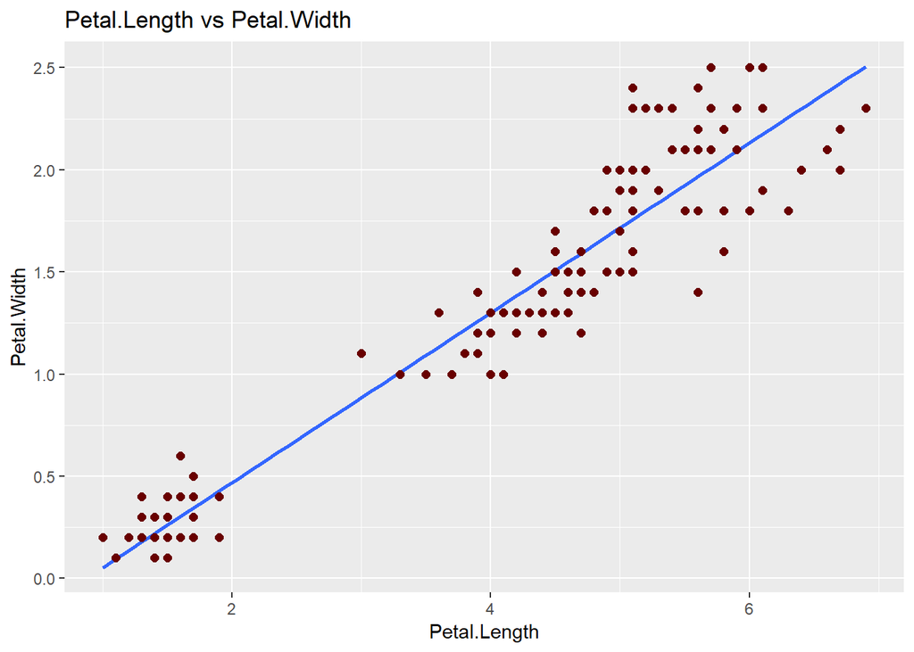

```r
ggplot(data=tibble.iris, aes(x=Petal.Length , y=Petal.Width)) +
  stat_smooth(method = "lm", se = FALSE) +
  geom_point(size=2, color="#690000") +
  ggtitle("Petal.Length vs Petal.Width") +
  labs(x="Petal.Length" , y="Petal.Width")
```

**2.g** Modify previous plot by using different colors for each species only for the scatter chart and not for the regression line.

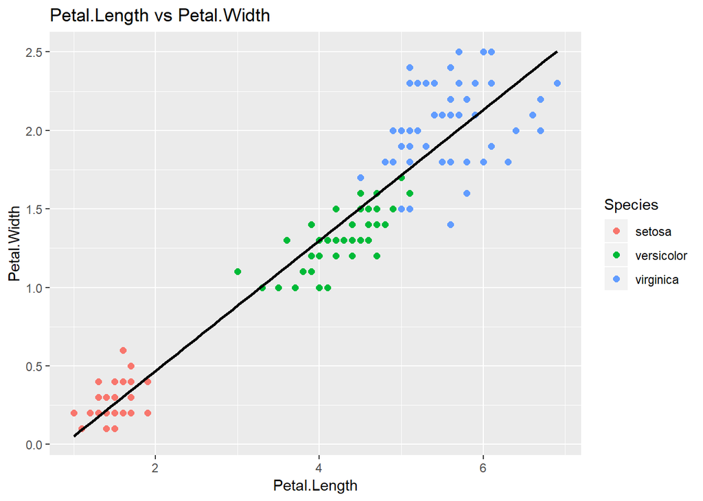

```r
ggplot(data=tibble.iris, aes(x=Petal.Length , y=Petal.Width, color = Species)) +
  geom_point(size=2) +
  ggtitle("Petal.Length vs Petal.Width") +
  labs(x="Petal.Length" , y="Petal.Width")+
  geom_smooth(method=lm, se=FALSE, fullrange=TRUE , color="black")
```

#### Exercise 3: House Prices

In this exercise, you will work with the [house prices dataset obtained from Kaggle](https://www.kaggle.com/c/house-prices-advanced-regression-techniques/data). The dataset contains 81 columns describing (almost) every aspect of residential homes in Ames, Iowa.

**3.a** Save the [data file](https://raw.githubusercontent.com/tvatter/dsfba_2019/homework/data/house_prices.csv) in `data` folder of your project. Load the dataset into the global environment by using function `read_csv` and assign it to variable `house_prices`. Make sure that the class of `house_prices` is a tibble.

```r
#downloaded from kaggle
house_prices <-as_tibble(read_csv("data/house_prices.csv"))
kable(head(house_prices))
```

| Id | MSSubClass | MSZoning | LotFrontage | LotArea | Street | Alley | LotShape | LandContour | Utilities | LotConfig | LandSlope | Neighborhood | Condition1 | Condition2 | BldgType | HouseStyle | OverallQual | OverallCond | YearBuilt | YearRemodAdd | RoofStyle | RoofMatl | Exterior1st | Exterior2nd | MasVnrType | MasVnrArea | ExterQual | ExterCond | Foundation | … |
| --- | --- | --- | --- | --- | --- | --- | --- | --- | --- | --- | --- | --- | --- | --- | --- | --- | --- | --- | --- | --- | --- | --- | --- | --- | --- | --- | --- | --- | --- | --- |
| 1 | 60 | RL | 65 | 8450 | Pave | NA | Reg | Lvl | AllPub | Inside | Gtl | CollgCr | Norm | Norm | 1Fam | 2Story | 7 | 5 | 2003 | 2003 | Gable | CompShg | VinylSd | VinylSd | BrkFace | 196 | Gd | TA | PConc | … |
| 2 | 20 | RL | 80 | 9600 | Pave | NA | Reg | Lvl | AllPub | FR2 | Gtl | Veenker | Feedr | Norm | 1Fam | 1Story | 6 | 8 | 1976 | 1976 | Gable | CompShg | MetalSd | MetalSd | None | 0 | TA | TA | CBlock | … |
| 3 | 60 | RL | 68 | 11250 | Pave | NA | IR1 | Lvl | AllPub | Inside | Gtl | CollgCr | Norm | Norm | 1Fam | 2Story | 7 | 5 | 2001 | 2002 | Gable | CompShg | VinylSd | VinylSd | BrkFace | 162 | Gd | TA | PConc | … |
| 4 | 70 | RL | 60 | 9550 | Pave | NA | IR1 | Lvl | AllPub | Corner | Gtl | Crawfor | Norm | Norm | 1Fam | 2Story | 7 | 5 | 1915 | 1970 | Gable | CompShg | Wd Sdng | Wd Shng | None | 0 | TA | TA | BrkTil | … |
| 5 | 60 | RL | 84 | 14260 | Pave | NA | IR1 | Lvl | AllPub | FR2 | Gtl | NoRidge | Norm | Norm | 1Fam | 2Story | 8 | 5 | 2000 | 2000 | Gable | CompShg | VinylSd | VinylSd | BrkFace | 350 | Gd | TA | PConc | … |
| 6 | 50 | RL | 85 | 14115 | Pave | NA | IR1 | Lvl | AllPub | Inside | Gtl | Mitchel | Norm | Norm | 1Fam | 1.5Fin | 5 | 5 | 1993 | 1995 | Gable | CompShg | VinylSd | VinylSd | None | 0 | TA | TA | Wood | … |

**3.b** You will work with only four variables, namely, `LotArea`, `KitchenQual`, `LotShape`, and `SalePrice`, which indicate area (in square feet), kitchen quality, general shape, and sale price (in dollars) of property. Modify `house_prices` to have only these four columns, as well as transform `LotArea` from square feet into square meters. Bonus: try to use only one `dplyr` function.

```r
house_prices <- house_prices %>%
  select(LotArea, KitchenQual,LotShape,SalePrice) %>%
  mutate(LotArea = (LotArea/10.764))

kable(head(house_prices))
```

| LotArea | KitchenQual | LotShape | SalePrice |
| --- | --- | --- | --- |
| 785 | Gd | Reg | 208500 |
| 892 | TA | Reg | 181500 |
| 1045 | Gd | IR1 | 223500 |
| 887 | Gd | IR1 | 140000 |
| 1325 | Gd | IR1 | 250000 |
| 1311 | TA | IR1 | 143000 |

**3.c** For how many lots have the sale price was greater than its mean value?

```r
NbrHousewithHigherthanaveragePrice <-house_prices %>% filter(SalePrice>mean(SalePrice)) %>% summarise(Nbr_of_house=n())

kable(head(NbrHousewithHigherthanaveragePrice))
```

| Nbr_of_house |
| --- |
| 560 |

**3.d** Display the average sale price for each kitchen quality level.

Note, levels of `KitchenQual` correspond to the followin values:

```
- Ex -- Excellent,
- Gd -- Good,
- TA -- Typical/Average,
- Fa -- Fair
- Po -- Poor
```

```r
MeanPrice <-house_prices %>%
  mutate(KitchenQual = recode(KitchenQual, Ex = "Excellent",
         Gd = "Good", TA = "Typical/Average",Fa = "Fair"))   %>%
  group_by(KitchenQual) %>%
  summarise(MeanPrice=mean(SalePrice))

kable(MeanPrice)
```

| KitchenQual | MeanPrice |
| --- | --- |
| Excellent | 328555 |
| Fair | 105565 |
| Good | 212116 |
| Typical/Average | 139963 |

**3.e** Display ten randomly selected observations from the dataset. What happens if you execute your code a few times? How can you make sure that each execution returns the exact 10 rows?

```r
kable(sample_n(house_prices, size=10))
```

| LotArea | KitchenQual | LotShape | SalePrice |
| --- | --- | --- | --- |
| 847 | Gd | Reg | 185000 |
| 804 | TA | Reg | 160000 |
| 1100 | TA | Reg | 118500 |
| 716 | TA | IR1 | 150000 |
| 3391 | TA | IR1 | 190000 |
| 787 | TA | IR1 | 151000 |
| 975 | TA | Reg | 143000 |
| 1054 | TA | IR1 | 121500 |
| 1310 | Gd | IR1 | 381000 |
| 338 | Gd | Reg | 175900 |

```r
#It's never the same data so to be sure to have the same data we ccan set a seed such as :

set.seed(2)
kable(sample_n(house_prices, size=10))
```

| LotArea | KitchenQual | LotShape | SalePrice |
| --- | --- | --- | --- |
| 736 | TA | IR1 | 148000 |
| 1440 | Gd | IR1 | 287000 |
| 892 | Gd | Reg | 128000 |
| 825 | Gd | IR1 | 205000 |
| 987 | Gd | Reg | 250000 |
| 906 | Gd | Reg | 274300 |
| 967 | TA | Reg | 135000 |
| 1127 | TA | IR1 | 164000 |
| 924 | TA | IR1 | 128500 |
| 1256 | Ex | Reg | 485000 |

**3.f** Print out the minimum price of observations for which shape is regular (i.e., `"Reg"`), and the kitchen has excellent quality.

```r
Filter <- house_prices %>%  filter(LotShape=="Reg", KitchenQual== "Ex")  %>%
  summarise("Minimum price of houses with regular shape and high quality kitchen" = min(SalePrice))

kable(head(Filter))
```

| Minimum price of houses with regular shape and high quality kitchen |
| --- |
| 86000 |

**3.g** Produce boxplots with kitchen quality as the x-axis and the price as the y-axis. Regroup kitchen quality in the following order: excellent, good, typical/average, and fair. What can you say about the relationship between kitchen quality and the price?

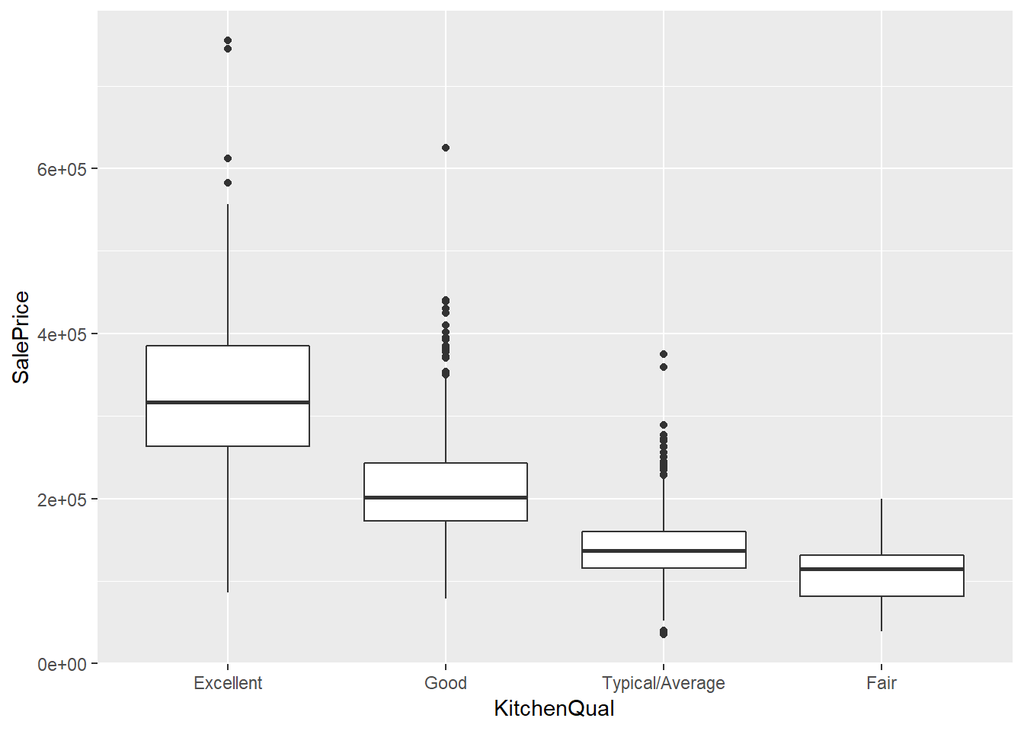

```r
house_prices_renames <-house_prices %>%
  mutate(KitchenQual = recode(KitchenQual, Ex = "Excellent",
         Gd = "Good", TA = "Typical/Average",Fa = "Fair"))

house_prices_renames$KitchenQual<-factor(house_prices_renames$KitchenQual, levels=c("Excellent", "Good", "Typical/Average","Fair"))



ggplot(data = house_prices_renames, mapping = aes(x = KitchenQual, y = SalePrice)) +
  geom_boxplot()
```

```r
#We can notice that higher is the kitchen quality higher is the sale price on average
```

**3.h** Draw a scatter chart to investigate the dependence between `LotArea` and `SalePrice`. Further, use different colors depending on the kitchen quality, and different shapes depending on the shape of the property.

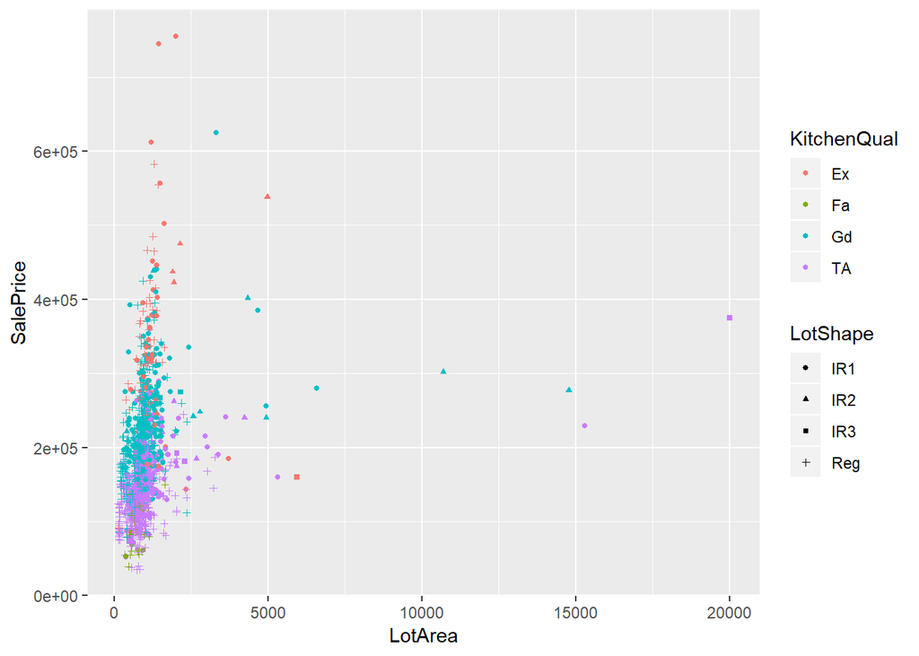

```r
ggplot(data=house_prices, aes(x=LotArea , y=SalePrice, color = KitchenQual, shape= LotShape))+
  geom_point(size=1)
```